# Testing Independence of Multiple Networks

Youjin Lee

- Networks vs. Attributes
- Networks vs. Networks

## Networks vs. Attributes

Suppose we have $N$ measures of same networks, e.g. $N$ individuals’ brain connectivity, and suppose we are interested in dependence between brain connectivity and person’s personality factors. Using all $N$ measures of networks and also $N$ measures of person’s personality would reduce the measurement errors so that it better tests independence between network and attibutes. Suppose $(G_{z}, Y_{z})$ is a pair of $i$th individual’s observations. ($z=1,.., N$), and let $(G_{z}, Y_{z}) \sim^{iid} (\textbf{G}, \textbf{Y})$ $z =1,...,N.$

$H_{0} : f_{\textbf{GY}} = f_{\textbf{G}} f_{\textbf{Y}}$

Each observations $z$ follows such latnet variable dependent models.

$(X^{z}_{1}, Y^{z}_{1}), (X^{z}_{2}, Y^{z}_{2}) , ... , (X^{z}_{n}, Y^{z}_{n}) \overset{i.i.d}{\sim} N \left( \begin{bmatrix} 0 \\ 0 \end{bmatrix}, \begin{bmatrix}1 & \rho_{z} \\ \rho_{z} & 1 \end{bmatrix} \right)$

$\log \left( \frac{P\big( T^{z}_{ij} \big) }{1 - P\big( T^{z}_{ij} \big) } \big| X_i, X_j \right) = f \big( | X^{z}_i - X^{z}_j | \big)$

$f\big( |X^{z}_i - X^{z}_j| \big) = \left\{ \begin{array}{cc} |X^{z}_i - X^{z}_j| & \max(0.01, |X^{z}_i - X^{z}_j| ) < 0.10 \\ -20 |X^{z}_{i} - X^{z}_{j}| & \mbox{ o.w.} \end{array} \right.$

1. $N=10$ independent observations; $\rho_{z} = 0.1 \forall z$ ; $n=300$ ; $M=500$

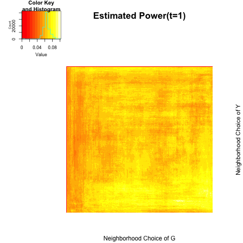

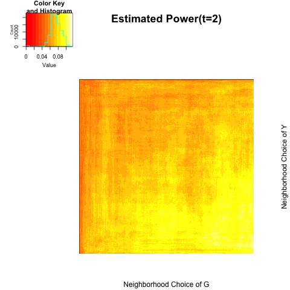

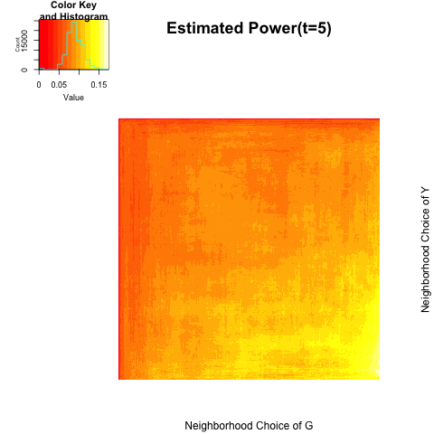

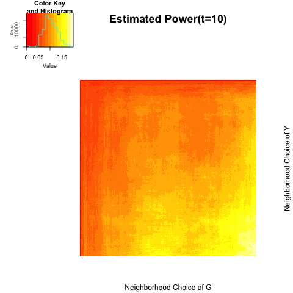

|  | t=1 | t=2 | t=5 | t=10 |
| --- | --- | --- | --- | --- |
| global test | 0.07 | 0.09 | 0.14 | 0.18 |
| local optimal | 0.10 | 0.12 | 0.17 | 0.20 |

2. $N=3$; 3 Blocks; $\rho_{1} = (0, 0.1) \sim (50\%, 50\%) ; \rho_{2} = (0.1, 0) \sim (50\%, 50\%); \rho_{3} = (0, 0.1, 0.2) \sim (33\%, 33\%, 33\%); n =300; M=300$

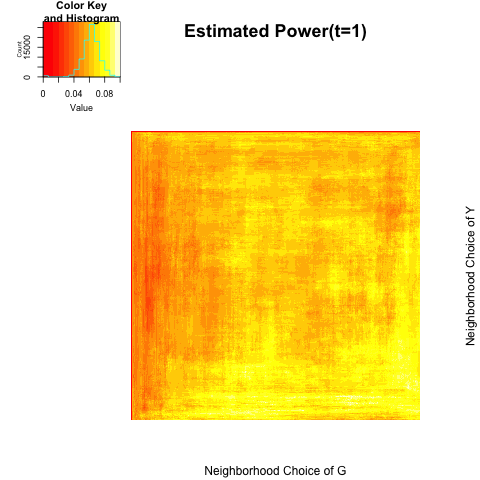

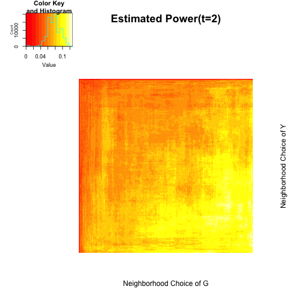

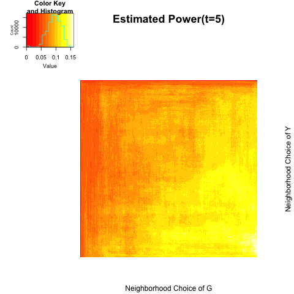

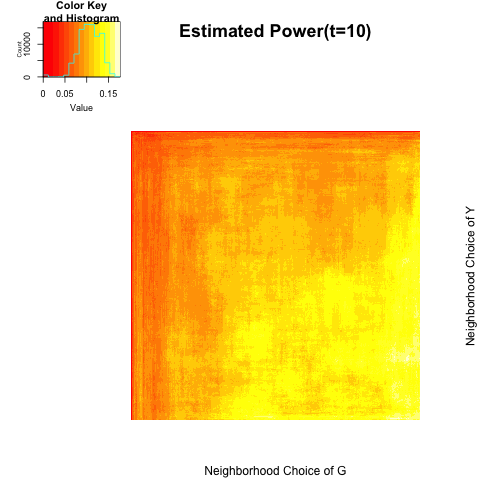

|  | t=1 | t=2 | t=5 | t=10 |
| --- | --- | --- | --- | --- |
| global test | 0.07 | 0.10 | 0.12 | 0.15 |
| local optimal | 0.10 | 0.13 | 0.16 | 0.18 |

3. $N=10$ ; $(\rho_{1} ,... ,\rho_{5}) = 0.2; (\rho_{5}, ... , \rho_{10}) = 0.0$

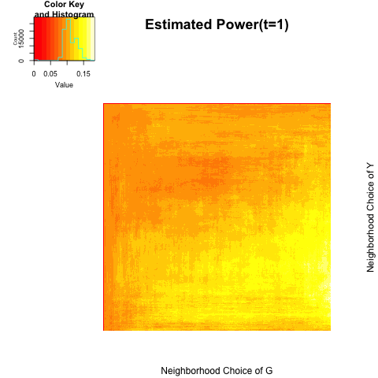

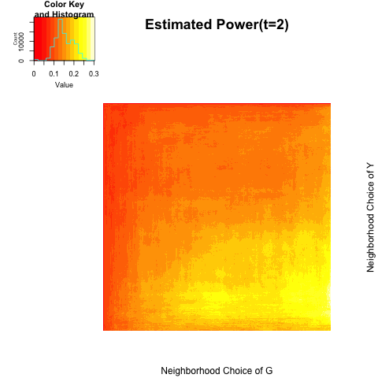

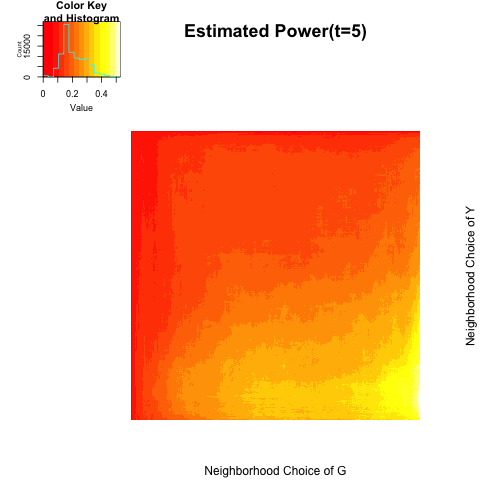

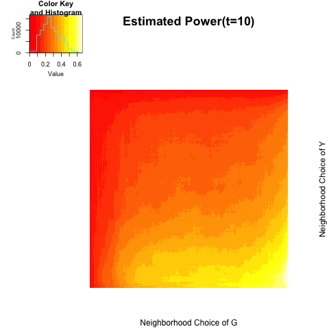

|  | t=1 | t=2 | t=5 | t=10 |
| --- | --- | --- | --- | --- |
| global test | 0.11 | 0.2 | 0.42 | 0.61 |
| local optimal | 0.18 | 0.3 | 0.53 | 0.66 |